# Лабораторная работа №7

Адресация IPv4 и IPv6. Настройка DHCP

Лисовская А.В.

Российский университет дружбы народов, Москва, Россия

4 февраля 2026

## Докладчик

- Лисовская Арина Валерьевна
- Студентка группы НПИбд01-23
- Российский университет дружбы народов
- 1132236894@pfur.ru

[figure not shown]

## Цель работы

- Изучение принципов работы протокола DHCP (Dynamic Host Configuration Protocol).
- Получение практических навыков настройки службы DHCP на сетевом оборудовании.
- Организация автоматического распределения адресов IPv4 и IPv6 в локальной сети.
- Анализ механизмов Stateful и Stateless для IPv6.

## Теоретическое введение

- **DHCP** — протокол, позволяющий устройствам автоматически получать IP-адрес и параметры сети (шлюз, DNS).
- **Модель работы**: Клиент-сервер (UDP порты 67/68 для IPv4, 546/547 для IPv6).
- **DHCPv6**:
  - **Stateless**: Клиент получает префикс через RA (Router Advertisement), а доп. параметры через DHCP.
  - **Stateful**: Сервер полностью управляет выдачей адресов и хранит информацию о состоянии (leases).

## Настройка инфраструктуры

- В качестве сетевого оборудования используется маршрутизатор под управлением VyOS.
- Клиентские узлы представлены виртуальными машинами (PC).
- Основная задача: настроить маршрутизатор как DHCP-сервер для сегмента сети.

## Выполнение работы: Настройка IPv4 DHCP

- Определение пула адресов и исключение статических IP.
- Указание параметров сети:
  - Сетевой адрес и маска.
  - Шлюз по умолчанию (Default Router).
  - Адреса DNS-серверов.
- Привязка DHCP-сервера к конкретному интерфейсу маршрутизатора.

## Выполнение работы: Конфигурация Stateful DHCPv6

- Создание пула адресов для IPv6.
- Настройка диапазона выдачи (например, `2001::100` – `2001::199`).
- Настройка интерфейса `eth1` маршрутизатора:
  - Включение флагов `managed-config` и `other-config` в Router Advertisement.
  - Это заставляет клиентов запрашивать адрес именно у DHCPv6 сервера.

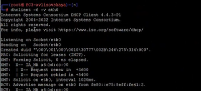

## Проверка на стороне клиента (PC3)

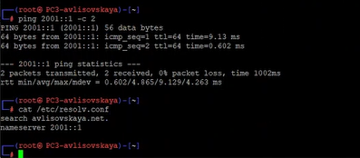

Проверка сетевых настроек клиента

## Контроль состояния сервера

- Проверка таблицы аренды (lease table) на маршрутизаторе.
- Команда: `show dhcpv6 server leases`.
- В выводе отображается выданный IPv6-адрес, DUID клиента и время истечения аренды.

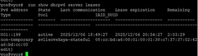

Таблица активных аренд DHCPv6

[figure not shown]

Захват трафика ICMPv6

[figure not shown]

## Выводы

1. DHCP является критически важным протоколом для масштабируемых сетей, минимизируя ошибки ручной настройки.
2. Механизмы IPv6 предлагают гибкость (Stateless/Stateful), что отличает их от классического IPv4 DHCP.
3. Навыки работы с CLI маршрутизатора и анализаторами трафика позволяют эффективно диагностировать сетевые неполадки.